# Multivariate Regression on the WHO Life expectancy dataset

### About the data:

The Global Health Observatory (GHO) data repository under World Health Organization (WHO) keeps track of the health status as well as many other related factors for all countries The datasets are made available to public for the purpose of health data analysis. The dataset related to life expectancy, health factors for 193 countries has been collected from the same WHO data repository website and its corresponding economic data was collected from United Nation website. Among all categories of health-related factors only those critical factors were chosen which are more representative. It has been observed that in the past 15 years , there has been a huge development in health sector resulting in improvement of human mortality rates especially in the developing nations in comparison to the past 30 years. Therefore, in this project we have considered data from year 2000-2015 for 193 countries for further analysis. The individual data files have been merged together into a single dataset. On initial visual inspection of the data showed some missing values. As the datasets were from WHO, we found no evident errors. Missing data was handled in R software by using Missmap command. The result indicated that most of the missing data was for population, Hepatitis B and GDP. The missing data were from less known countries like Vanuatu, Tonga, Togo,Cabo Verde etc. Finding all data for these countries was difficult and hence, it was decided that we exclude these countries from the final model dataset. The final merged file(final dataset) consists of 22 Columns and 2938 rows which meant 20 predicting variables. All predicting variables was then divided into several broad categories:Immunization related factors, Mortality factors, Economical factors and Social factors.

### DATA DICTIONARY

#### Country

Country

#### Year

Year

#### Status

Developed or Developing status

#### Life expectancy

Life Expectancy in age

#### Adult Mortality

Adult Mortality Rates of both sexes (probability of dying between 15 and 60 years per 1000 population)

#### infant deaths

Number of Infant Deaths per 1000 population

#### Alcohol

Alcohol, recorded per capita (15+) consumption (in litres of pure alcohol)

#### percentage expenditure

Expenditure on health as a percentage of Gross Domestic Product per capita(%)

#### Hepatitis B

Hepatitis B (HepB) immunization coverage among 1-year-olds (%)

#### Measles

Measles - number of reported cases per 1000 population

#### BMI

Average Body Mass Index of entire population

#### under-five deaths

Number of under-five deaths per 1000 population

#### Polio

Polio (Pol3) immunization coverage among 1-year-olds (%)

#### Total expenditure

General government expenditure on health as a percentage of total government expenditure (%)

#### Diphtheria

Diphtheria tetanus toxoid and pertussis (DTP3) immunization coverage among 1-year-olds (%)

#### HIV/AIDS

Deaths per 1 000 live births HIV/AIDS (0-4 years)

#### GDP

Gross Domestic Product per capita (in USD)

#### Population

Population of the country

#### thinness 1-19 years

Prevalence of thinness among children and adolescents for Age 10 to 19 (% )

#### thinness 5-9 years

Prevalence of thinness among children for Age 5 to 9(%)

#### Income composition of resources

Human Development Index in terms of income composition of resources (index ranging from 0 to 1)

#### Schooling

Number of years of Schooling(years)

```r
life_expectancy<-read.csv("Life Expectancy Data.csv")
dim(life_expectancy)
```

```
[1] 2938   22
```

```r
summary(life_expectancy)
```

```
   Country               Year         Status          Life.expectancy
 Length:2938        Min.   :2000   Length:2938        Min.   :36.30
 Class :character   1st Qu.:2004   Class :character   1st Qu.:63.10
 Mode  :character   Median :2008   Mode  :character   Median :72.10
                    Mean   :2008                      Mean   :69.22
                    3rd Qu.:2012                      3rd Qu.:75.70
                    Max.   :2015                      Max.   :89.00
                                                      NA's   :10
 Adult.Mortality infant.deaths       Alcohol        percentage.expenditure
 Min.   :  1.0   Min.   :   0.0   Min.   : 0.0100   Min.   :    0.000
 1st Qu.: 74.0   1st Qu.:   0.0   1st Qu.: 0.8775   1st Qu.:    4.685
 Median :144.0   Median :   3.0   Median : 3.7550   Median :   64.913
 Mean   :164.8   Mean   :  30.3   Mean   : 4.6029   Mean   :  738.251
 3rd Qu.:228.0   3rd Qu.:  22.0   3rd Qu.: 7.7025   3rd Qu.:  441.534
 Max.   :723.0   Max.   :1800.0   Max.   :17.8700   Max.   :19479.912
 NA's   :10                       NA's   :194
  Hepatitis.B       Measles              BMI        under.five.deaths
 Min.   : 1.00   Min.   :     0.0   Min.   : 1.00   Min.   :   0.00
 1st Qu.:77.00   1st Qu.:     0.0   1st Qu.:19.30   1st Qu.:   0.00
 Median :92.00   Median :    17.0   Median :43.50   Median :   4.00
 Mean   :80.94   Mean   :  2419.6   Mean   :38.32   Mean   :  42.04
 3rd Qu.:97.00   3rd Qu.:   360.2   3rd Qu.:56.20   3rd Qu.:  28.00
 Max.   :99.00   Max.   :212183.0   Max.   :87.30   Max.   :2500.00
 NA's   :553                        NA's   :34
     Polio       Total.expenditure   Diphtheria       HIV.AIDS
 Min.   : 3.00   Min.   : 0.370    Min.   : 2.00   Min.   : 0.100
 1st Qu.:78.00   1st Qu.: 4.260    1st Qu.:78.00   1st Qu.: 0.100
 Median :93.00   Median : 5.755    Median :93.00   Median : 0.100
 Mean   :82.55   Mean   : 5.938    Mean   :82.32   Mean   : 1.742
 3rd Qu.:97.00   3rd Qu.: 7.492    3rd Qu.:97.00   3rd Qu.: 0.800
 Max.   :99.00   Max.   :17.600    Max.   :99.00   Max.   :50.600
 NA's   :19      NA's   :226       NA's   :19
      GDP              Population        thinness..1.19.years
 Min.   :     1.68   Min.   :3.400e+01   Min.   : 0.10
 1st Qu.:   463.94   1st Qu.:1.958e+05   1st Qu.: 1.60
 Median :  1766.95   Median :1.387e+06   Median : 3.30
 Mean   :  7483.16   Mean   :1.275e+07   Mean   : 4.84
 3rd Qu.:  5910.81   3rd Qu.:7.420e+06   3rd Qu.: 7.20
 Max.   :119172.74   Max.   :1.294e+09   Max.   :27.70
 NA's   :448         NA's   :652         NA's   :34
 thinness.5.9.years Income.composition.of.resources   Schooling
 Min.   : 0.10      Min.   :0.0000                  Min.   : 0.00
 1st Qu.: 1.50      1st Qu.:0.4930                  1st Qu.:10.10
 Median : 3.30      Median :0.6770                  Median :12.30
 Mean   : 4.87      Mean   :0.6276                  Mean   :11.99
 3rd Qu.: 7.20      3rd Qu.:0.7790                  3rd Qu.:14.30
 Max.   :28.60      Max.   :0.9480                  Max.   :20.70
 NA's   :34         NA's   :167                     NA's   :163
```

```r
life_expectancy$Country<-as.factor(life_expectancy$Country)
life_expectancy$Status<-as.factor(life_expectancy$Status)
```

```r
summary(life_expectancy)
```

```
                Country          Year             Status     Life.expectancy
 Afghanistan        :  16   Min.   :2000   Developed : 512   Min.   :36.30
 Albania            :  16   1st Qu.:2004   Developing:2426   1st Qu.:63.10
 Algeria            :  16   Median :2008                     Median :72.10
 Angola             :  16   Mean   :2008                     Mean   :69.22
 Antigua and Barbuda:  16   3rd Qu.:2012                     3rd Qu.:75.70
 Argentina          :  16   Max.   :2015                     Max.   :89.00
 (Other)            :2842                                    NA's   :10
 Adult.Mortality infant.deaths       Alcohol        percentage.expenditure
 Min.   :  1.0   Min.   :   0.0   Min.   : 0.0100   Min.   :    0.000
 1st Qu.: 74.0   1st Qu.:   0.0   1st Qu.: 0.8775   1st Qu.:    4.685
 Median :144.0   Median :   3.0   Median : 3.7550   Median :   64.913
 Mean   :164.8   Mean   :  30.3   Mean   : 4.6029   Mean   :  738.251
 3rd Qu.:228.0   3rd Qu.:  22.0   3rd Qu.: 7.7025   3rd Qu.:  441.534
 Max.   :723.0   Max.   :1800.0   Max.   :17.8700   Max.   :19479.912
 NA's   :10                       NA's   :194
  Hepatitis.B       Measles              BMI        under.five.deaths
 Min.   : 1.00   Min.   :     0.0   Min.   : 1.00   Min.   :   0.00
 1st Qu.:77.00   1st Qu.:     0.0   1st Qu.:19.30   1st Qu.:   0.00
 Median :92.00   Median :    17.0   Median :43.50   Median :   4.00
 Mean   :80.94   Mean   :  2419.6   Mean   :38.32   Mean   :  42.04
 3rd Qu.:97.00   3rd Qu.:   360.2   3rd Qu.:56.20   3rd Qu.:  28.00
 Max.   :99.00   Max.   :212183.0   Max.   :87.30   Max.   :2500.00
 NA's   :553                        NA's   :34
     Polio       Total.expenditure   Diphtheria       HIV.AIDS
 Min.   : 3.00   Min.   : 0.370    Min.   : 2.00   Min.   : 0.100
 1st Qu.:78.00   1st Qu.: 4.260    1st Qu.:78.00   1st Qu.: 0.100
 Median :93.00   Median : 5.755    Median :93.00   Median : 0.100
 Mean   :82.55   Mean   : 5.938    Mean   :82.32   Mean   : 1.742
 3rd Qu.:97.00   3rd Qu.: 7.492    3rd Qu.:97.00   3rd Qu.: 0.800
 Max.   :99.00   Max.   :17.600    Max.   :99.00   Max.   :50.600
 NA's   :19      NA's   :226       NA's   :19
      GDP              Population        thinness..1.19.years
 Min.   :     1.68   Min.   :3.400e+01   Min.   : 0.10
 1st Qu.:   463.94   1st Qu.:1.958e+05   1st Qu.: 1.60
 Median :  1766.95   Median :1.387e+06   Median : 3.30
 Mean   :  7483.16   Mean   :1.275e+07   Mean   : 4.84
 3rd Qu.:  5910.81   3rd Qu.:7.420e+06   3rd Qu.: 7.20
 Max.   :119172.74   Max.   :1.294e+09   Max.   :27.70
 NA's   :448         NA's   :652         NA's   :34
 thinness.5.9.years Income.composition.of.resources   Schooling
 Min.   : 0.10      Min.   :0.0000                  Min.   : 0.00
 1st Qu.: 1.50      1st Qu.:0.4930                  1st Qu.:10.10
 Median : 3.30      Median :0.6770                  Median :12.30
 Mean   : 4.87      Mean   :0.6276                  Mean   :11.99
 3rd Qu.: 7.20      3rd Qu.:0.7790                  3rd Qu.:14.30
 Max.   :28.60      Max.   :0.9480                  Max.   :20.70
 NA's   :34         NA's   :167                     NA's   :163
```

```r
life_expectancy_4years<-life_expectancy%>%
  filter(Year==2015|Year==2014|Year==2013|Year==2012)
life_expectancy_4years<-drop_na(life_expectancy_4years)
```

```r
life_expectancy1<-life_expectancy_4years%>%
  group_by(Country, Status)%>%
  summarise(Life.expectancy=mean(Life.expectancy), Adult.Mortality=mean(Adult.Mortality), infant.deaths=mean(infant.deaths), Alcohol=mean(Alcohol), percentage.expenditure=mean(percentage.expenditure), Hepatitis.B=mean(Hepatitis.B) ,Measles=mean(Measles), BMI=mean(BMI), under.five.deaths=mean(under.five.deaths), Polio=mean(under.five.deaths), Total.expenditure=mean(Total.expenditure),Diphtheria=mean(Diphtheria), HIV.AIDS=mean(HIV.AIDS), GDP=mean(GDP), Population=mean(Population), thinness..1.19.years=mean(thinness..1.19.years),thinness.5.9.years=mean(thinness.5.9.years),Income.composition.of.resources=mean(Income.composition.of.resources),Schooling=mean(Schooling))
```

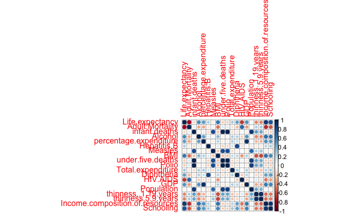

```r
p<-cor(life_expectancy1[c(3:21)])
corrplot::corrplot(p)
```

```r
DF<-life_expectancy1[c(2,3,4,6,7,8,9,10,11,13:20)]
```

```r
model<-lm(Life.expectancy~.,data = DF)
```

```r
summary(model)
```

```
Call:
lm(formula = Life.expectancy ~ ., data = DF)

Residuals:
     Min       1Q   Median       3Q      Max
-10.6012  -1.4405  -0.0318   1.5347   6.8254

Coefficients:
                                  Estimate Std. Error t value Pr(>|t|)
(Intercept)                      4.940e+01  2.895e+00  17.067  < 2e-16 ***
StatusDeveloping                -1.006e+00  9.941e-01  -1.012   0.3139
Adult.Mortality                 -1.850e-02  4.546e-03  -4.071 8.67e-05 ***
Alcohol                         -6.644e-02  9.893e-02  -0.672   0.5032
percentage.expenditure           6.941e-04  3.972e-04   1.747   0.0833 .
Hepatitis.B                      3.635e-03  2.515e-02   0.145   0.8853
Measles                         -2.103e-05  1.034e-04  -0.203   0.8392
BMI                              3.006e-03  2.309e-02   0.130   0.8967
under.five.deaths               -3.882e-03  4.964e-03  -0.782   0.4358
Total.expenditure                3.423e-01  1.274e-01   2.686   0.0083 **
Diphtheria                       1.835e-02  3.202e-02   0.573   0.5678
HIV.AIDS                        -8.736e-01  2.008e-01  -4.352 2.96e-05 ***
GDP                             -9.762e-05  6.209e-05  -1.572   0.1187
Population                       1.260e-08  1.088e-08   1.158   0.2492
thinness..1.19.years            -6.775e-02  2.084e-01  -0.325   0.7458
thinness.5.9.years               2.681e-02  2.024e-01   0.132   0.8949
Income.composition.of.resources  3.298e+01  4.019e+00   8.207 3.89e-13 ***
---
Signif. codes:  0 ‘***’ 0.001 ‘**’ 0.01 ‘*’ 0.05 ‘.’ 0.1 ‘ ’ 1

Residual standard error: 2.853 on 114 degrees of freedom
Multiple R-squared:  0.899, Adjusted R-squared:  0.8849
F-statistic: 63.44 on 16 and 114 DF,  p-value: < 2.2e-16
```

```r
model<-lm(Life.expectancy~Adult.Mortality+Total.expenditure+HIV.AIDS+Income.composition.of.resources,data = DF)
```

```r
summary(model)
```

```
Call:
lm(formula = Life.expectancy ~ Adult.Mortality + Total.expenditure +
    HIV.AIDS + Income.composition.of.resources, data = DF)

Residuals:
     Min       1Q   Median       3Q      Max
-10.6290  -1.4207  -0.0437   1.7727   7.9983

Coefficients:
                                 Estimate Std. Error t value Pr(>|t|)
(Intercept)                     48.666773   1.972393  24.674  < 2e-16 ***
Adult.Mortality                 -0.019132   0.004304  -4.445 1.90e-05 ***
Total.expenditure                0.423488   0.115729   3.659  0.00037 ***
HIV.AIDS                        -0.899525   0.190746  -4.716 6.28e-06 ***
Income.composition.of.resources 34.410418   2.300096  14.960  < 2e-16 ***
---
Signif. codes:  0 ‘***’ 0.001 ‘**’ 0.01 ‘*’ 0.05 ‘.’ 0.1 ‘ ’ 1

Residual standard error: 2.81 on 126 degrees of freedom
Multiple R-squared:  0.8918,    Adjusted R-squared:  0.8883
F-statistic: 259.5 on 4 and 126 DF,  p-value: < 2.2e-16
```

#### Life.expectancy = 48.66-(0.019*adult.mortality)+0.423*Total.expenditure-0.899*HIV.AIDS+34.41*Income.composition.of.resources